# Average Utilization vs Revenue-Weighted Service Optimization

Findings-led objective comparison in the 3×3 patient-behavior factorial

This report asks a focused question:

> **For the same clinic background and policy regime, what changes when the optimizer values a completed Class 1 visit twice as much as a Class 2 visit?**

The comparison is **objective-to-objective**, not policy-to-baseline.

Average-utilization optimization values completed visits equally. The weighted objective is

$$W_2=\frac{2Y_1+Y_2}{2M},$$

so within a clinic background it ranks policies equivalently to maximizing $2Y_1+Y_2$.

For every background and policy regime:

1. the average-utilization objective and the 2× Class 1 objective are optimized independently;
2. both frozen policy cells are evaluated on the same 10 independent seeds;
3. every reported effect is **weighted-optimal minus average-utilization-optimal**.

# 1 3×3 patient-behavior design

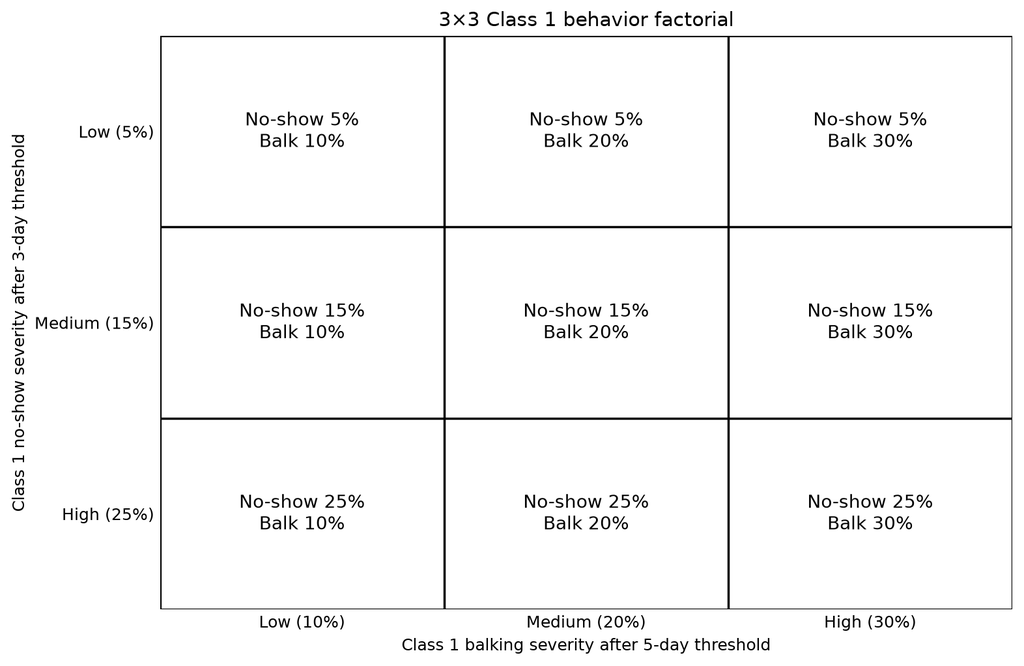

The current Class 1 behavior factorial.

The factorial changes only Class 1 severity:

- no-show threshold fixed at **3 days**, with post-threshold probability **5%, 15%, 25%**;
- balking threshold fixed at **5 days**, with post-threshold probability **10%, 20%, 30%**;
- pre-threshold probability is **5%** for both behaviors;
- Class 2 behavior is fixed throughout.

The headline range is $\rho\le2.5$.

# 2 Finding 1 — Revenue weighting changes who is served more than how much is served

The key consequence of the 2× Class 1 objective is **access redistribution**, not a large change in total completed service.

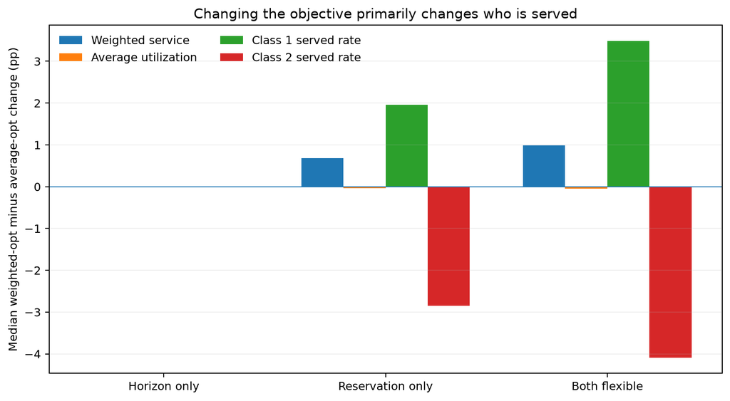

Median objective-switch effects by policy. Positive Class 1 and negative Class 2 changes indicate redistribution toward the priority class.

- **Horizon only:** weighted service +0.00 pp; average utilization +0.00 pp; Class 1 served rate +0.00 pp; Class 2 served rate +0.00 pp.

- **Reservation only:** weighted service +0.69 pp; average utilization -0.03 pp; Class 1 served rate +1.96 pp; Class 2 served rate -2.85 pp.

- **Both flexible:** weighted service +0.99 pp; average utilization -0.04 pp; Class 1 served rate +3.48 pp; Class 2 served rate -4.09 pp.

**Interpretation:** if weighted service rises while average utilization stays near zero, the objective is achieving its gain mainly by **redirecting scarce capacity toward Class 1**, not by generating many additional completed visits.

# 3 Finding 2 — Reservation capacity is the direct lever for changing the priority mix

The objective switch can matter only if the policy family gives the optimizer a way to favor Class 1. Reservation-capable policies have the clearest direct lever because they can change protected capacity.

| Policy | Same exact policy cell | Median ΔH | Median ΔQ | Median Δwindow |
| --- | --- | --- | --- | --- |
| Both flexible | 1.8% | +1.0 | +6.0 | +1.0 |
| Horizon only | 52.7% | +0.0 | +0.0 | +0.0 |
| Reservation only | 6.4% | +0.0 | +4.0 | +6.0 |

- **Both flexible** has the largest median absolute Class 1 access response to changing the objective (3.48 pp).

- The **same-cell percentage** shows how often changing the objective does not change the selected policy parameters at all.

- Changes in **Q/window** indicate that the weighted objective is using reservation protection directly; changes in **H** indicate that it is also changing delay exposure.

# 4 Finding 3 — Patient behavior changes how valuable the objective switch is

The objective switch is not equally consequential in every behavior cell.

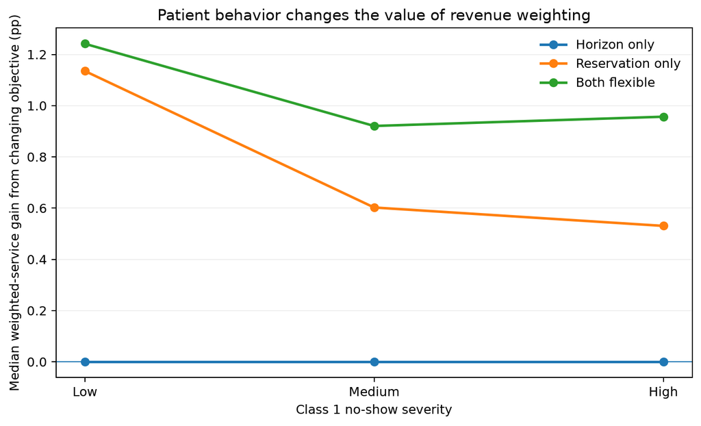

Weighted-service gain from changing the objective by Class 1 no-show severity.

The matched high-minus-low contrasts identify whether **no-show** or **balking** changes the value of revenue weighting more strongly.

| Policy | Behavior | Weighted service effect | Average utilization effect | Class 1 effect | Class 2 effect |
| --- | --- | --- | --- | --- | --- |
| Horizon only | No-show | -0.03 pp | -0.01 pp | -0.07 pp | +0.07 pp |
| Horizon only | Balking | +0.01 pp | -0.00 pp | +0.04 pp | -0.02 pp |
| Reservation only | No-show | -1.96 pp | -0.07 pp | -5.68 pp | +4.52 pp |
| Reservation only | Balking | +0.06 pp | -0.01 pp | +0.09 pp | -0.07 pp |
| Both flexible | No-show | -0.80 pp | +0.01 pp | -1.39 pp | +1.55 pp |
| Both flexible | Balking | -0.06 pp | +0.00 pp | -0.09 pp | +0.24 pp |

- **Horizon only:** no-show severity is the clearer behavioral modifier of weighted-objective value (-0.03 pp high-minus-low versus +0.01 pp for balking).

- **Reservation only:** no-show severity is the clearer behavioral modifier of weighted-objective value (-1.96 pp high-minus-low versus +0.06 pp for balking).

- **Both flexible:** no-show severity is the clearer behavioral modifier of weighted-objective value (-0.80 pp high-minus-low versus -0.06 pp for balking).

The point of the 3×3 analysis is therefore not to show nine separate curves. It is to identify **which behavioral dimension materially changes the objective tradeoff**.

# 5 Finding 4 — Class 1 population share changes the cost of prioritization

When a larger share of demand belongs to the priority class, the amount of Class 2 displacement required to improve Class 1 access can change substantially.

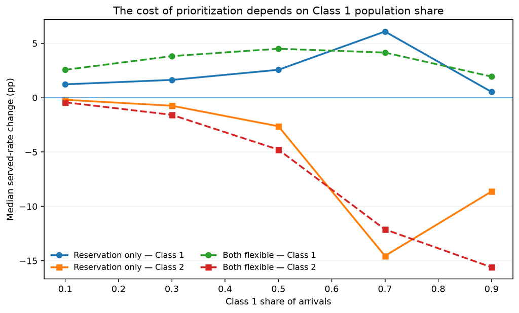

Class-specific objective-switch effects by Class 1 population share for reservation-capable policies.

- **Reservation only:** the largest median Class 1 shift occurs at Class 1 share 0.7 (+6.09 pp), while the largest median Class 2 shift occurs at share 0.7 (-14.56 pp).

- **Both flexible:** the largest median Class 1 shift occurs at Class 1 share 0.5 (+4.50 pp), while the largest median Class 2 shift occurs at share 0.9 (-15.60 pp).

**Interpretation:** the same 2× weighting rule can imply a very different access tradeoff depending on how large the priority population is.

# 6 Win/neutral situations — favorable objective switches are the exception, not the default

Using the same ±0.5 percentage-point practical band as the average-utilization report:

- **Win-win:** both classes improve by at least +0.5 pp and both 95% CIs are above zero.
- **C1 win / C2 neutral:** Class 1 improves by at least +0.5 pp with CI above zero, while the entire Class 2 CI stays inside ±0.5 pp.
- **C2 win / C1 neutral:** the symmetric case.

The report does **not** list every favorable background. It summarizes only the recurring trends.

| Policy | Case type | Cases | Share of backgrounds |
| --- | --- | --- | --- |
| Both flexible | C1 win / C2 neutral | 18 | 4.0% |
| Horizon only | C1 win / C2 neutral | 4 | 0.9% |
| Horizon only | C2 win / C1 neutral | 6 | 1.3% |
| Reservation only | C1 win / C2 neutral | 16 | 3.6% |

## 6.1 Trends among the favorable cases

- **Both flexible — C1 win / C2 neutral:** recurring features are rho = 2.0/2.5 (9/18); Class 1 share = 0.1 (18/18); capacity = 50 (18/18).

- **Horizon only — C1 win / C2 neutral:** recurring features are no-show = High (3/4); balking = High (2/4); rho = 1.7 (3/4); Class 1 share = 0.1 (4/4); capacity = 30 (3/4).

- **Horizon only — C2 win / C1 neutral:** recurring features are no-show = High/Medium (3/6); rho = 2.5 (6/6); Class 1 share = 0.9 (6/6); capacity = 50 (6/6).

- **Reservation only — C1 win / C2 neutral:** recurring features are no-show = High (9/16); rho = 2.5 (10/16); Class 1 share = 0.1 (16/16); capacity = 50 (11/16).

A characteristic is surfaced only when the same value appears in at least **50%** of that policy × case-type group. This keeps the section focused on trends rather than individual scenarios.

# 7 Conclusions

- **Changing the objective primarily changes the distribution of access, not total throughput.**
- **Reservation protection is the most direct mechanism for translating a 2× Class 1 weight into a different service mix.**
- **The 3×3 design identifies which patient behavior materially changes the value of weighting instead of averaging all behavior profiles together.**
- **Class 1 population share changes the size of the access tradeoff.**
- **Win-win and win/neutral cases should be treated as special operating regions, not as the typical consequence of revenue weighting.**

The clinic decision is therefore an **objective-choice decision**: use the weighted objective when additional Class 1 service is explicitly worth the accompanying redistribution identified in the relevant patient-behavior and population-share scenario.

Primary data inputs:

- `full_run_summaries/patient_behavior_factorial_3_5/release/selected_policy_seed_outcomes.csv`
- `full_run_summaries/patient_behavior_factorial_3_5/release/selected_policy_outcomes.csv`

All objective-switch results are matched within the **same background, policy regime, and independent evaluation seed**.